# BL40A2020 Wireless Communication Systems

## Assignment week 2: Analog communication

## Author: Jesse Peltola

```python
! pip install scikit-dsp-comm
```

### A) Follow the steps done in the [notes](https://github.com/pedrohjn/wireless-comm/blob/master/Week%202/week2.ipynb) to analyze the *Conventional AM* (Sec. 3.2.2)

```python
import sympy as sp
sp.init_printing()
import sk_dsp_comm as ss
import scipy.signal as signal
import scipy.fftpack as fftpack
import numpy as np
import matplotlib.pyplot as plt
from matplotlib import style
style.use('bmh')
import warnings
warnings.filterwarnings('ignore')
```

**1. Define a generic message $m(t) = A_\mathrm{m} \cos(2\pi f_\mathrm{m} t + \phi)$ and modulation equation [from eq. (3.5) p.96](https://www.ece.ucsb.edu/wcsl/Publications/intro_comm_systems_madhow_jan2014b.pdf) using sympy.**

```python
m, t, Am, fm, f, w = sp.symbols('a, t, A_m, f_m, f, phi')
A, fc, Ac = sp.symbols('A, f_c, A_c')

g = sp.Function('g')
print('Generic message signal')
m = Am * sp.cos(2 * sp.pi * fm * t + w)
m
```

```
Generic message signal
```

$\displaystyle A_{m} \cos{\left(2 \pi f_{m} t + \phi \right)}$

```python
print("AM modulation equation")
U_AM = A * g(t) * sp.cos(2 * sp.pi * fc * t) + (Ac * sp.cos(2 * sp.pi * fc * t))
U_AM
```

```
AM modulation equation
```

$\displaystyle A g{\left(t \right)} \cos{\left(2 \pi f_{c} t \right)} + A_{c} \cos{\left(2 \pi f_{c} t \right)}$

```python
#Consider that g(t) = m(t)

print ("DSB-modulated cosine message signal")
U_AM.subs(g(t), m)
```

```
DSB-modulated cosine message signal
```

$\displaystyle A A_{m} \cos{\left(2 \pi f_{c} t \right)} \cos{\left(2 \pi f_{m} t + \phi \right)} + A_{c} \cos{\left(2 \pi f_{c} t \right)}$

**2. Numerical example:**

- Message: $m(t) = \cos{\left (8 \pi t + \frac{\pi}{3} \right )}$
- Modulation parameters: $A = A_\mathrm{c} = 2$ and $f_\mathrm{c} = 50$

(a) Plot the message, the transmitted signal, and their respective spectrum domain. Note that you should probably use other python libraries (scipy, numpy, and other for signal processing).

```python
print("Message") # w is equal to phi
m_2 = m.subs(Am, 1).subs(fm, 4).subs(w, sp.pi/3)
m_2
```

```
Message
```

$\displaystyle \cos{\left(8 \pi t + \frac{\pi}{3} \right)}$

```python
amp_m = 2
amp_c = 2
freq_c = 50
print("AM Modulated signal")
#modulated_signal = U_AM.subs(fc, freq_c).subs(A, amp_c).subs(g(t), m_2)
modulated_signal = U_AM.subs(g(t), m_2).subs(A, 2).subs(Ac, 2).subs(fc, 50)
modulated_signal
```

```
AM Modulated signal
```

$\displaystyle 2 \cos{\left(100 \pi t \right)} \cos{\left(8 \pi t + \frac{\pi}{3} \right)} + 2 \cos{\left(100 \pi t \right)}$

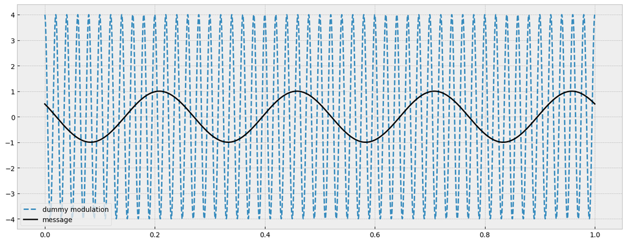

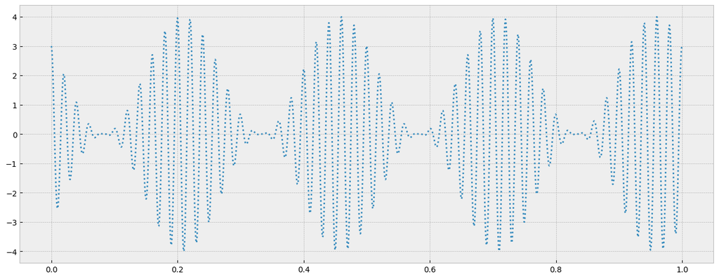

```python
message = sp.lambdify(t, m_2, "numpy")
# message =  sp.lambdify(t,m.subs(Am,amp_m ).subs(fm, 1),"numpy")
#modulation_only = sp.lambdify(t,U_AM.subs(fc,freq_c).subs(A,amp_c).subs(g(t),1),"numpy")
modulation_only = sp.lambdify(t, U_AM.subs(g(t), 1).subs(A, 2).subs(Ac, 2).subs(fc, 50), "numpy")
modulated = sp.lambdify(t, modulated_signal, "numpy")

#Initializing the plot message

fp = 4000
tp = np.linspace(0, 1, fp)
plt.rcParams['figure.figsize'] = 16, 6
plt.plot(tp, modulation_only(tp), linestyle='--', label='dummy modulation')
plt.plot(tp, message(tp), 'k-', label='message')
plt.legend(loc='lower left')
plt.show()
plt.plot(tp, modulated(tp), ':')
plt.show()
```

$\displaystyle \left( -5.0, \ 5.0\right)$

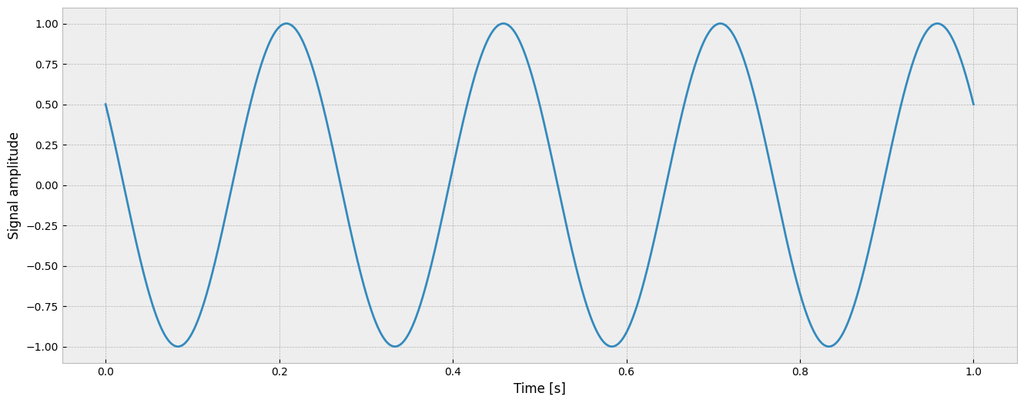

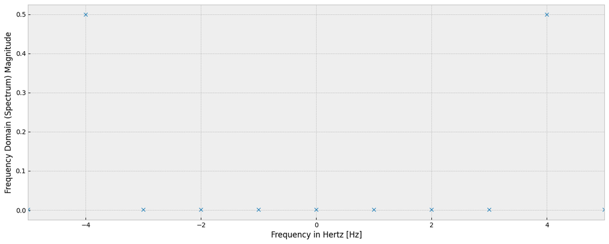

```python
freq_m = 1
x = message(tp)
fig, ax = plt.subplots()
ax.plot(tp, x)
ax.set_xlabel('Time [s]')
ax.set_ylabel('Signal amplitude');
X = fftpack.fft(x)/ fp
freqs = fftpack.fftfreq(len(x)) * fp

fig, ax = plt.subplots()
ax.plot(freqs, np.abs(X),'x')

ax.set_xlabel('Frequency in Hertz [Hz]')
ax.set_ylabel('Frequency Domain (Spectrum) Magnitude')
ax.set_xlim(-5, 5)
```

(b) Implement the demodulation remembering that the message can be directly recovered by the envelope.

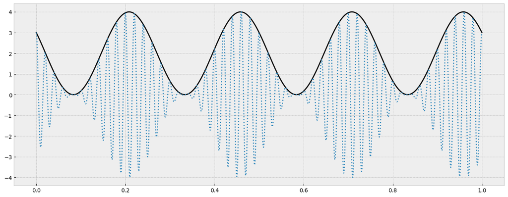

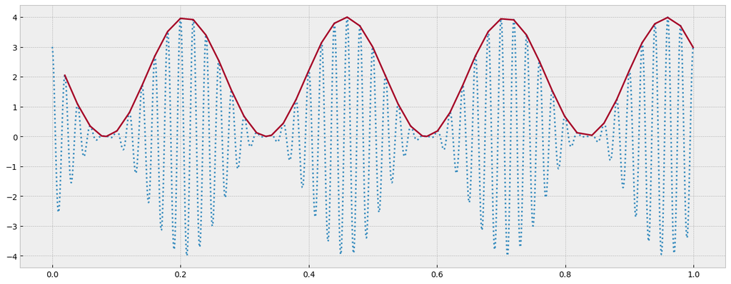

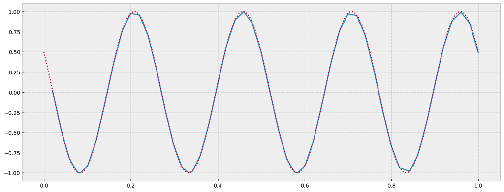

```python
plt.plot(tp, np.abs(2*message(tp) + 2), 'k-', label='2*message')
plt.plot(tp, modulated(tp), ':')
plt.show()
peaks, _ = signal.find_peaks(modulated(tp), height=0)
peaks

plt.plot(tp, modulated(tp), ':')
plt.plot(peaks/fp, modulated(peaks/fp))
plt.show()

plt.plot(peaks/fp, (modulated(peaks/fp) - 2) / 2)
plt.plot(tp, message(tp), ":")
plt.show()
```

### B) Explain with your own words and in few lines the difference between *Angle Modulations* and *Amplidute Modulations*.

The difference between Angle modulations and Amplitude modulations is that Angle modulation is used for embedding the baseband message signal in the phase or the frequency of a passband waveform. Amplitude modulations are used for embedding the baseband message signal in the amplitude of a sinusoidal carrier.

The message can be demodulated by using the envelope detector which means that carrier synchronoziation is not needed. If it is about DSB-DC demodulation, then the carrier synchronoziation is needed.